# IODS course project

# Chapter 5: Dimensionality reduction techniques

In this chapter, we learn the basics of two data science based ways of reducing the dimensions. The key method is principal component analysis (PCA), which reduces any number of measured (continuous) and correlated variables into a few uncorrelated components that collect together as much variance as possible from the original variables. Multiple correspondence analysis (MCA) and other variations of CA bring us similar possibilities in the world of discrete variables, even nominal scale (classified) variables, by finding a suitable transformation into continuous scales and then reducing the dimensions quite analogously with the PCA.

```r
# Load the data
human <- read.csv("Z:\\IODS\\IODS\\data\\human.csv")
```

**1 Graphical overview of the data**

```r
library(dplyr)
summary(human)
```

```
##   SE_fm_ratio     LFPR_fm_ratio         EYoE            LEaB
##  Min.   :0.1717   Min.   :0.1857   Min.   : 5.40   Min.   :49.00
##  1st Qu.:0.7264   1st Qu.:0.5984   1st Qu.:11.25   1st Qu.:66.30
##  Median :0.9375   Median :0.7535   Median :13.50   Median :74.20
##  Mean   :0.8529   Mean   :0.7074   Mean   :13.18   Mean   :71.65
##  3rd Qu.:0.9968   3rd Qu.:0.8535   3rd Qu.:15.20   3rd Qu.:77.25
##  Max.   :1.4967   Max.   :1.0380   Max.   :20.20   Max.   :83.50
##      GNIpC             MMR              ABR              PRP
##  Min.   :   581   Min.   :   1.0   Min.   :  0.60   Min.   : 0.00
##  1st Qu.:  4198   1st Qu.:  11.5   1st Qu.: 12.65   1st Qu.:12.40
##  Median : 12040   Median :  49.0   Median : 33.60   Median :19.30
##  Mean   : 17628   Mean   : 149.1   Mean   : 47.16   Mean   :20.91
##  3rd Qu.: 24512   3rd Qu.: 190.0   3rd Qu.: 71.95   3rd Qu.:27.95
##  Max.   :123124   Max.   :1100.0   Max.   :204.80   Max.   :57.50
```

SE_fm_ratio = the ratio of Female and Male populations with secondary education

LFPR_fm_ratio = the ratio of labour force participation of females and males

EYoE = Expected Years of Education

LEaB = Life Expectancy at Birth

GNIpC = Gross National Income GNI per Capita

MMR = Maternal Mortality Ratio

ABR = Adolescent Birth Rate

PRP = Percent Representation in Parliament

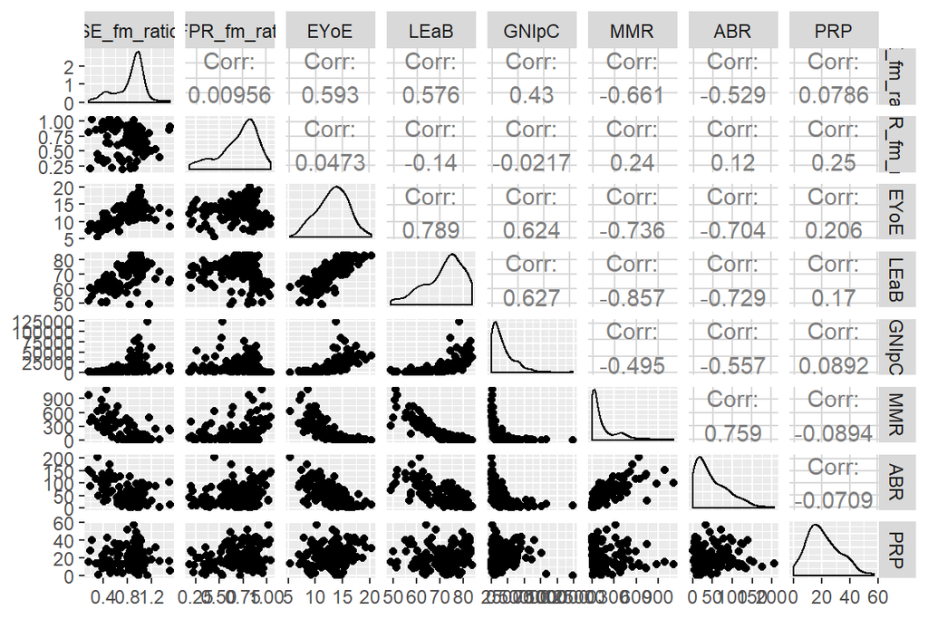

```r
library(GGally)
ggpairs(human)
```

**2 Principal component analysis (PCA)**

```r
# perform principal component analysis (with the SVD method)
pca_human <- prcomp(human)
s <- summary(pca_human)

# the percentages of variance
pca_pr <- round(100*s$importance[2, ], digits = 1)
pca_pr
```

```
## PC1 PC2 PC3 PC4 PC5 PC6 PC7 PC8
## 100   0   0   0   0   0   0   0
```

PC1 captures all of the variability in the data.

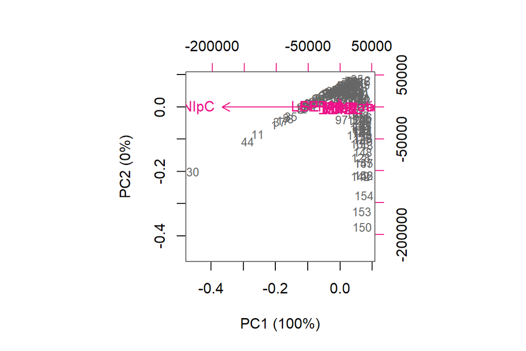

```r
# create object pc_lab to be used as axis labels
pc_lab <- paste0(names(pca_pr), " (", pca_pr, "%)")

# draw a biplot
biplot(pca_human, cex = c(0.8, 1), col = c("grey40", "deeppink2"), xlab = pc_lab[1], ylab = pc_lab[2])
```

In the non standardized data, Gross National Income has much larger variance than the rest of the variables. PCA assumes that variables with larger variance are more important than variables with smaller variance. Therefore, the long arrow of Gross National Income dominates the figure, and the rest of the arrows are of length zero. PC1 simply captures the variability of the variable with largest variance, Gross National Income, and countries with low values on this variable are to the right side of the plot (most countries) and countries with high values are to the left side of the plot.

**3 Principal component analysis (PCA), standardized data**

```r
# standardize the variables
human_std <- scale(human)

# perform principal component analysis (with the SVD method)
pca_human_std <- prcomp(human_std)
s_std <- summary(pca_human_std)

# the percentages of variance
pca_pr_std <- round(100*s_std$importance[2, ], digits = 1)
pca_pr_std
```

```
##  PC1  PC2  PC3  PC4  PC5  PC6  PC7  PC8
## 53.6 16.2  9.6  7.6  5.5  3.6  2.6  1.3
```

Now PC1 captures 53.6 percent of the variability in the data and PC2 16.2 percent. Using these two components, we fail to explain ~30 percent of the variability in the data.

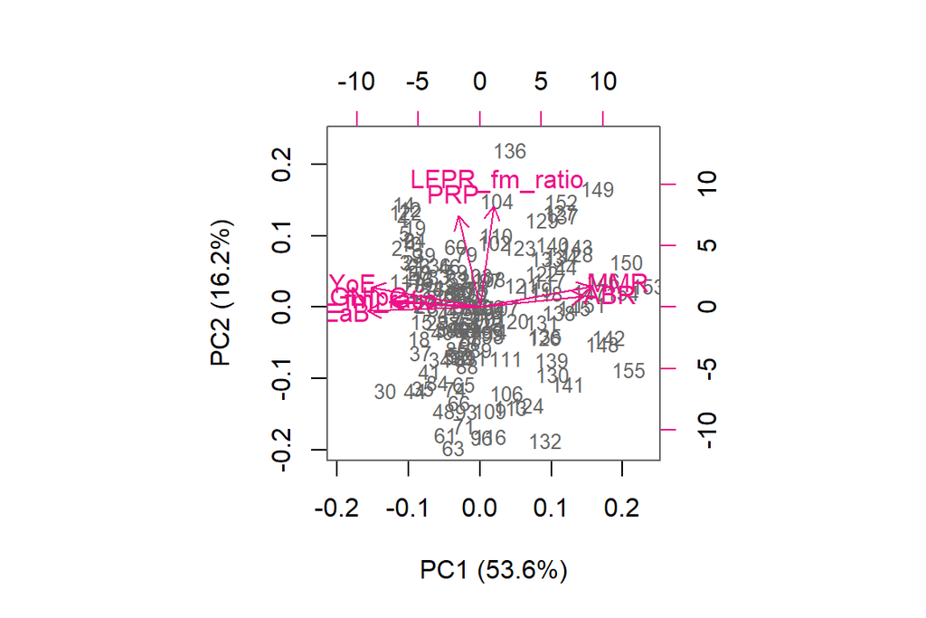

```r
# create object pc_lab to be used as axis labels
pc_lab_std <- paste0(names(pca_pr_std), " (", pca_pr_std, "%)")

# draw a biplot
biplot(pca_human_std, cex = c(0.8, 1), col = c("grey40", "deeppink2"), xlab = pc_lab_std[1], ylab = pc_lab_std[2])
```

The data set is now standardized, meaning that the variance is 1 for all variables. All arrows are therefore of similar length, and none of them dominate the figure like in the non standardized case.

The small angle between Maternal mortality ratio and Adolescent birth rate shows the strong positive correlation between them. Expected years of education, Life expectancy at birth and Gross National Income are positivley correlated with each other, but negatively correlated with Maternal mortality ratio and Adolescent birth rate (due to the wide angle between them). Percent Representation in Parliament and the ratio of labour force participation of females and males are positivley correlated with each other, but these are not correlated with the feature that PC1 represents (due to orthogonality between them).

**4 Personal interpretations**

PC1 captures the overall health and development in a country. To the left is “healthy” countries with high life expectancy and low maternal mortality and to he right is “unhealthy” countries with high frequency of teenage births and low expected years of education.

PC2 captures the degree of gender equality in a country, where gender equality is measured by the ratio of labour force participation of females and males and by Percent Representation in Parliament.

As we can see from the figure, Nordic and Western European countries are in the left top of the figure and ranks high in both health and equality. Oppositely, in the rigth bottom with bad health and low gender equality is for example Niger.

**5 The tea dataset**

I decided to limit the data set right from the start. The new data set “tea_time” consists of 9 variables and 300 observations.

```r
library(FactoMineR)
library(tidyr)
library(ggplot2)
data("tea")

# column names to keep in the dataset
keep_columns <- c("Tea", "work", "pub","How", "sex", "SPC", "breakfast", "relaxing","slimming")

# select the 'keep_columns' to create a new dataset
tea_time <- dplyr::select(tea, one_of(keep_columns))

# look at the summaries and structure of the data
summary(tea_time)
```

```
##         Tea            work          pub         How      sex
##  black    : 74   Not.work:213   Not.pub:237   alone:195   F:178
##  Earl Grey:193   work    : 87   pub    : 63   lemon: 33   M:122
##  green    : 33                                milk : 63
##                                               other:  9
##
##
##
##            SPC             breakfast          relaxing          slimming
##  employee    :59   breakfast    :144   No.relaxing:113   No.slimming:255
##  middle      :40   Not.breakfast:156   relaxing   :187   slimming   : 45
##  non-worker  :64
##  other worker:20
##  senior      :35
##  student     :70
##  workman     :12
```

```r
str(tea_time)
```

```
## 'data.frame':    300 obs. of  9 variables:
##  $ Tea      : Factor w/ 3 levels "black","Earl Grey",..: 1 1 2 2 2 2 2 1 2 1 ...
##  $ work     : Factor w/ 2 levels "Not.work","work": 1 1 2 1 1 1 1 1 1 1 ...
##  $ pub      : Factor w/ 2 levels "Not.pub","pub": 1 1 1 1 1 1 1 1 1 1 ...
##  $ How      : Factor w/ 4 levels "alone","lemon",..: 1 3 1 1 1 1 1 3 3 1 ...
##  $ sex      : Factor w/ 2 levels "F","M": 2 1 1 2 2 2 2 1 2 2 ...
##  $ SPC      : Factor w/ 7 levels "employee","middle",..: 2 2 4 6 1 6 5 2 5 5 ...
##  $ breakfast: Factor w/ 2 levels "breakfast","Not.breakfast": 1 1 2 2 1 2 1 2 1 1 ...
##  $ relaxing : Factor w/ 2 levels "No.relaxing",..: 1 1 2 2 2 2 2 2 2 2 ...
##  $ slimming : Factor w/ 2 levels "No.slimming",..: 1 1 1 1 1 1 1 1 1 1 ...
```

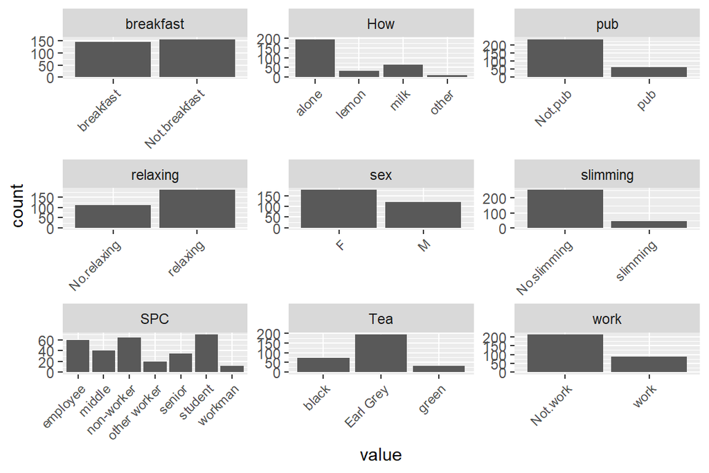

```r
# visualize the dataset
gather(tea_time) %>% ggplot(aes(value)) + facet_wrap("key", scales = "free") + geom_bar() + theme(axis.text.x = element_text(angle = 45, hjust = 1, size = 8))
```

Most of the variables have two categories, e.g. work/not work, pub/not pub, breakfast/ not breakfast, relaxing/no relaxing, slimming/no slimming, female/male. The variable “Tea” has three categories: “black”, “Earl Grey”, and “green”, “How” has four categories, and “SPC” has 7 categories.

There are more females and males in the dataset, and most participants are either a student, a non-worker, or an employee. Most participants drink Earl Grey, they drink it withouht milk/lemon or other, and almost half of them drink tea at breakfast. They do not drink tea at the pub or at work. Many participants find tea relaxing, but very few find it slimming.

```r
# multiple correspondence analysis
mca <- MCA(tea_time, graph = FALSE)

# summary of the model
summary(mca)
```

```
##
## Call:
## MCA(X = tea_time, graph = FALSE)
##
##
## Eigenvalues
##                        Dim.1   Dim.2   Dim.3   Dim.4   Dim.5   Dim.6
## Variance               0.183   0.169   0.154   0.132   0.127   0.123
## % of var.              9.685   8.929   8.146   6.995   6.719   6.518
## Cumulative % of var.   9.685  18.615  26.761  33.756  40.475  46.993
##                        Dim.7   Dim.8   Dim.9  Dim.10  Dim.11  Dim.12
## Variance               0.119   0.117   0.109   0.105   0.094   0.088
## % of var.              6.277   6.174   5.764   5.574   4.976   4.653
## Cumulative % of var.  53.270  59.445  65.209  70.782  75.758  80.411
##                       Dim.13  Dim.14  Dim.15  Dim.16  Dim.17
## Variance               0.083   0.080   0.078   0.069   0.060
## % of var.              4.417   4.223   4.128   3.643   3.178
## Cumulative % of var.  84.828  89.051  93.179  96.822 100.000
##
## Individuals (the 10 first)
##              Dim.1    ctr   cos2    Dim.2    ctr   cos2    Dim.3    ctr
## 1         |  0.645  0.759  0.248 | -0.029  0.002  0.001 | -0.116  0.029
## 2         |  0.638  0.742  0.208 |  0.241  0.115  0.030 |  0.028  0.002
## 3         | -0.343  0.214  0.052 | -0.086  0.015  0.003 | -0.308  0.205
## 4         | -0.338  0.208  0.125 | -0.357  0.252  0.140 | -0.136  0.040
## 5         | -0.020  0.001  0.000 |  0.024  0.001  0.001 | -0.184  0.073
## 6         | -0.338  0.208  0.125 | -0.357  0.252  0.140 | -0.136  0.040
## 7         |  0.332  0.201  0.079 |  0.171  0.058  0.021 | -0.377  0.307
## 8         |  0.378  0.261  0.079 | -0.024  0.001  0.000 |  0.182  0.071
## 9         |  0.598  0.651  0.202 |  0.430  0.365  0.105 | -0.382  0.316
## 10        |  0.616  0.691  0.225 |  0.175  0.060  0.018 | -0.095  0.019
##             cos2
## 1          0.008 |
## 2          0.000 |
## 3          0.042 |
## 4          0.020 |
## 5          0.033 |
## 6          0.020 |
## 7          0.101 |
## 8          0.018 |
```

[output cut: 23 more lines]

```
## alone     -0.121  0.690  0.027 -2.856 |
## lemon      0.328  0.857  0.013  1.996 |
## milk      -0.139  0.294  0.005 -1.241 |
##
## Categorical variables (eta2)
##             Dim.1 Dim.2 Dim.3
## Tea       | 0.274 0.303 0.194 |
## work      | 0.025 0.320 0.148 |
## pub       | 0.204 0.083 0.039 |
## How       | 0.191 0.198 0.198 |
## sex       | 0.266 0.000 0.067 |
## SPC       | 0.532 0.157 0.519 |
## breakfast | 0.034 0.341 0.001 |
## relaxing  | 0.093 0.008 0.084 |
## slimming  | 0.028 0.106 0.136 |
```

The first two dimensions explain only 18.6 percent of the variability in the data. Using only these two dimensions, quite a lot information “get lost”.

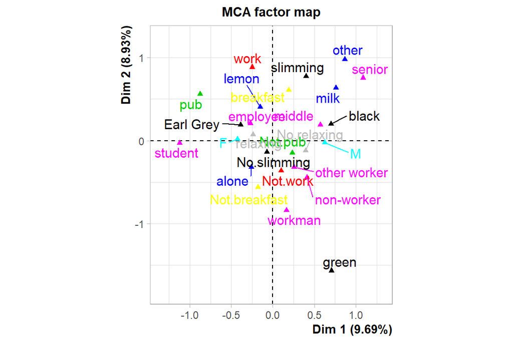

```r
# visualize MCA
plot(mca, invisible=c("ind"), habillage = "quali")
```

Categories close to each other are more similar than categories with a large distance.

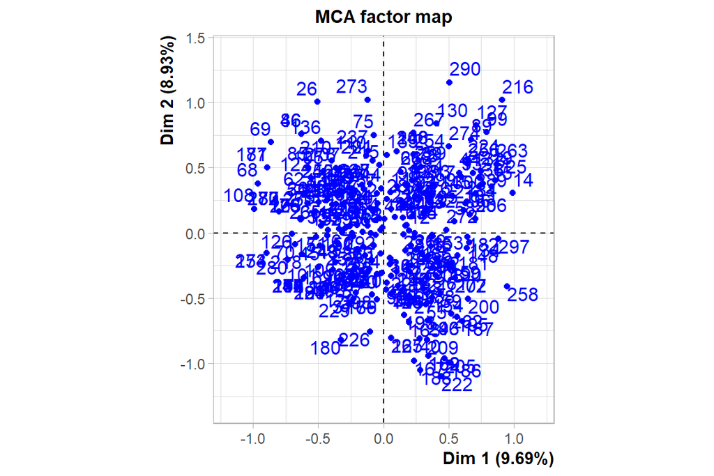

```r
# variable biplot
plot(mca, invisible=c("var"))
```

In the right top of the plot, we see seniors who prefer to drink their tea with milk or other. In the left top, we see employees who prefer Earl Grey with lemon.